# Advanced Microbiome Analyses

Edgardo L. Rosado Ramos

2025-11-21

# Analysis Overview

This report implements three advanced ecological analyses to deepen the understanding of the snake gut microbiome:

1. **The “Anna Karenina” Principle (Beta-Dispersion):** Testing if environmental stress (Sterile treatment) leads to increased microbiome variability (stochasticity).
2. **Developmental Trajectory:** Quantifying the “distance traveled” from the Newborn state over time.
3. **Functional Inference:** Mapping dominant taxa to known metabolic functions to predict the functional consequences of microbiome shifts.

# Setup & Data Loading

```r
library(phyloseq)
library(vegan)
library(tidyverse)
library(ggplot2)
library(ggpubr)
library(kableExtra)
library(RColorBrewer)

theme_set(theme_bw(base_size = 14))
```

```r
# Load OTU Table
otu_raw <- read.table("kohler.opti_mcc.0.03.subsample.shared", header = TRUE, sep = "\t")
otu_mat <- otu_raw[, -(1:3)]
rownames(otu_mat) <- otu_raw$Group
otu_mat <- t(otu_mat)
otu_tab <- otu_table(otu_mat, taxa_are_rows = TRUE)

# Load Taxonomy
tax_raw <- read.table("kohler.opti_mcc.0.03.cons.taxonomy",
                      sep = "\t", header = TRUE, stringsAsFactors = FALSE, quote = "")
taxonomy_strings <- tax_raw$Taxonomy
names(taxonomy_strings) <- tax_raw$OTU
taxonomy_clean <- lapply(strsplit(taxonomy_strings, ";"), function(x) {
  x <- x[nchar(x) > 0]
  x <- gsub("\\(.*?\\)|\\\"", "", x)
  trimws(x)
})
max_ranks <- 7
taxonomy_mat <- do.call(rbind, lapply(taxonomy_clean, `length<-`, max_ranks))
colnames(taxonomy_mat) <- c("Kingdom", "Phylum", "Class", "Order", "Family", "Genus", "Species")
rownames(taxonomy_mat) <- names(taxonomy_strings)
tax_tab <- tax_table(as.matrix(taxonomy_mat))

# Load Metadata
Kohler.design <- read.table("Kohlerdesign.txt",
                            header = TRUE, sep = "\t", row.names = 1,
                            stringsAsFactors = TRUE, check.names = FALSE)

# Create Phyloseq
common_samples <- intersect(sample_names(otu_tab), rownames(Kohler.design))
otu_tab_pruned <- prune_samples(common_samples, otu_tab)
sample_data_obj <- sample_data(Kohler.design[common_samples, ])
physeq <- phyloseq(otu_tab_pruned, tax_tab, sample_data_obj)

# Rarefy
physeq_filt <- filter_taxa(physeq, function(x) sum(x > 3) > (0.2 * length(x)), TRUE)
min_depth <- min(sample_sums(physeq_filt))
set.seed(42)
physeq_rarefied <- rarefy_even_depth(physeq_filt, sample.size = min_depth, replace = FALSE)
```

# Analysis 1: The “Anna Karenina” Principle (Beta-Dispersion)

**Hypothesis:** The “Sterile” environment lacks the consistent microbial inputs of the “Muck” environment. Therefore, Sterile microbiomes will be more variable (stochastic) between individuals than Muck microbiomes.

*“All healthy microbiomes are alike; each stressed microbiome is stressed in its own way.”*

```r
# Subset to relevant ages (7+ days onwards where treatment exists)
physeq_dev <- subset_samples(physeq_rarefied, Age %in% c("7+days", "15+days", "20+days"))

# Calculate Distance Matrix
bray_dist <- phyloseq::distance(physeq_dev, method = "bray")
metadata_dev <- data.frame(sample_data(physeq_dev))

# Calculate Multivariate Dispersion (Distance to Centroid)
beta_disp <- betadisper(bray_dist, metadata_dev$SampleType)

# Statistical Test (Permutation Test)
set.seed(42)
disp_test <- permutest(beta_disp, pairwise = TRUE, permutations = 999)

print(disp_test)
```

```
##
## Permutation test for homogeneity of multivariate dispersions
## Permutation: free
## Number of permutations: 999
##
## Response: Distances
##           Df  Sum Sq  Mean Sq     F N.Perm Pr(>F)
## Groups     1 0.01885 0.018850 0.452    999  0.516
## Residuals 24 1.00085 0.041702
##
## Pairwise comparisons:
## (Observed p-value below diagonal, permuted p-value above diagonal)
##            Muck Sterile
## Muck              0.504
## Sterile 0.50781
```

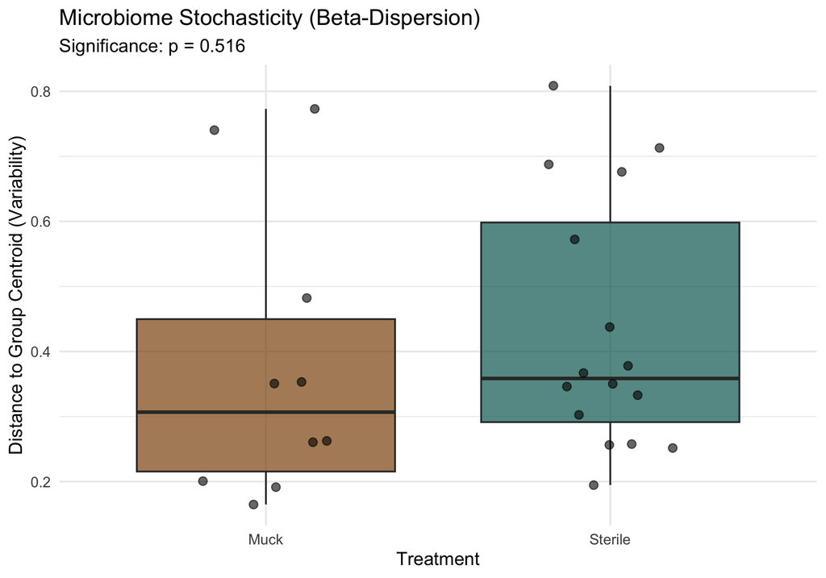

```r
# Extract distances for plotting
disp_df <- data.frame(
  Distance = beta_disp$distances,
  Group = metadata_dev$SampleType,
  Age = metadata_dev$Age
)

# Plot
p_disp <- ggplot(disp_df, aes(x = Group, y = Distance, fill = Group)) +
  geom_boxplot(alpha = 0.7, outlier.shape = NA) +
  geom_jitter(width = 0.2, size = 3, alpha = 0.6) +
  scale_fill_manual(values = c("Muck" = "#8c510a", "Sterile" = "#01665e")) +
  labs(
    title = "Microbiome Stochasticity (Beta-Dispersion)",
    subtitle = paste0("Significance: p = ", round(disp_test$tab$`Pr(>F)`[1], 3)),
    y = "Distance to Group Centroid (Variability)",
    x = "Treatment"
  ) +
  theme_minimal(base_size = 16) +
  theme(legend.position = "none")

print(p_disp)
```

**Interpretation:** - **Higher distance** = More variable/chaotic communities. - **Lower distance** = More consistent/deterministic communities. - If Sterile is higher, it suggests the lack of environmental microbes leads to stochastic assembly (random drift).

# Analysis 2: Developmental Trajectory

**Hypothesis:** We expect the microbiome to mature over time. Do “Muck” snakes develop *faster* or *differently* than “Sterile” snakes relative to the starting point (Newborns)?

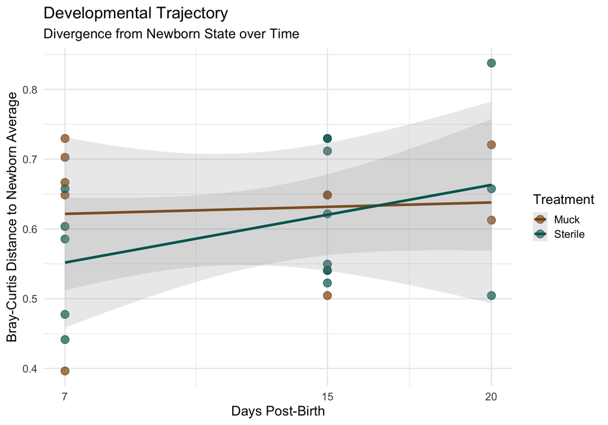

```r
# 1. Calculate the "Newborn Centroid" (The Baseline)
physeq_newborn <- subset_samples(physeq_rarefied, Age == "Newborn")
# We need the OTU table for newborns
otu_newborn <- as.data.frame(t(otu_table(physeq_newborn)))
# Calculate average abundance of every OTU in newborns
newborn_centroid <- colMeans(otu_newborn)

# 2. Calculate distance of EVERY sample to this Newborn Centroid
# We'll combine the centroid with the rest of the data to calc distances
otu_all <- as.data.frame(t(otu_table(physeq_rarefied)))
# Add centroid as a new row
otu_with_centroid <- rbind(otu_all, Newborn_Avg = newborn_centroid)

# Calculate Bray-Curtis distance matrix
dist_mat_traj <- vegan::vegdist(otu_with_centroid, method = "bray")
dist_mat_matrix <- as.matrix(dist_mat_traj)

# Extract distance of each sample to the "Newborn_Avg"
dist_to_newborn <- dist_mat_matrix[rownames(dist_mat_matrix) != "Newborn_Avg", "Newborn_Avg"]

# Create plotting data
traj_df <- data.frame(
  SampleID = names(dist_to_newborn),
  Dist_to_Newborn = dist_to_newborn,
  Age = sample_data(physeq_rarefied)$Age,
  Treatment = sample_data(physeq_rarefied)$SampleType
)

# Filter out Fetus/Newborn for the plot (we want to see trajectory AFTER birth)
traj_plot_df <- traj_df %>%
  filter(!Age %in% c("Fetus", "Newborn")) %>%
  mutate(Age_Numeric = case_when(
    Age == "7+days" ~ 7,
    Age == "15+days" ~ 15,
    Age == "20+days" ~ 20
  ))

# Plot
p_traj <- ggplot(traj_plot_df, aes(x = Age_Numeric, y = Dist_to_Newborn, color = Treatment, group = Treatment)) +
  geom_point(size = 4, alpha = 0.7) +
  geom_smooth(method = "lm", se = TRUE, alpha = 0.2) +
  scale_color_manual(values = c("Muck" = "#8c510a", "Sterile" = "#01665e")) +
  labs(
    title = "Developmental Trajectory",
    subtitle = "Divergence from Newborn State over Time",
    y = "Bray-Curtis Distance to Newborn Average",
    x = "Days Post-Birth"
  ) +
  scale_x_continuous(breaks = c(7, 15, 20)) +
  theme_minimal(base_size = 16)

print(p_traj)
```

**Interpretation:** - **Slope:** A steeper slope means the microbiome is changing *faster* away from the newborn state. - **Y-Intercept:** A higher value means the community shifted immediately after birth. - This tells us if the “Muck” environment accelerates microbiome maturation.

# Analysis 3: Functional Inference (Taxonomy-to-Function)

**Goal:** Infer the metabolic potential of the microbiome by mapping dominant taxa to their known biological functions.

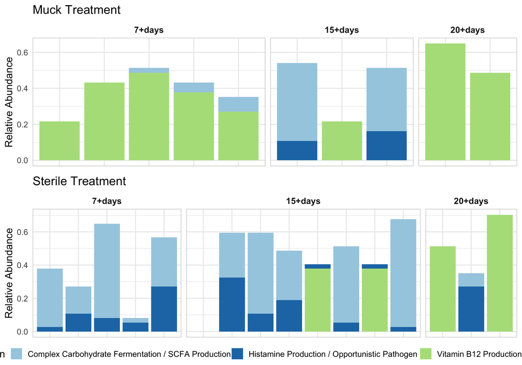

```r
# 1. Identify Top Genera
physeq_gen <- tax_glom(physeq_rarefied, taxrank = "Genus")
physeq_rel <- transform_sample_counts(physeq_gen, function(x) x / sum(x))
melted_gen <- psmelt(physeq_rel)

# Get top 10 genera by abundance
top_genera <- names(sort(tapply(melted_gen$Abundance, melted_gen$Genus, sum), decreasing = TRUE))[1:10]

# 2. Create Manual Function Map (Based on Literature)
# Note: This is a simplified mapping for demonstration.
# In a full paper, you would cite specific references for each.
func_map <- data.frame(
  Genus = c("Cetobacterium", "Bacteroides", "Morganella", "Proteus", "Clostridium", "Aeromonas", "Plesiomonas", "Enterococcus"),
  Function = c(
    "Vitamin B12 Production / Protein Fermentation", # Cetobacterium
    "Complex Carbohydrate Fermentation / SCFA Production", # Bacteroides
    "Histamine Production / Opportunistic Pathogen", # Morganella
    "Proteolytic Activity / Urea Hydrolysis", # Proteus
    "Spore Forming / Butyrate Production", # Clostridium
    "Chitin Degradation / Aquatic Opportunist", # Aeromonas
    "Aquatic Adaptation / Potential Pathogen", # Plesiomonas
    "Lactic Acid Production / Probiotic Potential" # Enterococcus
  )
)

# 3. Map Functions to Data
# Filter data to just top genera
func_data <- melted_gen %>%
  filter(Genus %in% func_map$Genus) %>%
  left_join(func_map, by = "Genus") %>%
  filter(!is.na(Function))

# Explicitly order Samples by Age for the plot
# Remove Fetus and Newborn as requested
age_levels <- c("7+days", "15+days", "20+days")

# Filter data to remove Fetus/Newborn
func_data <- func_data %>%
  filter(Age %in% age_levels)

# Re-order metadata and factor levels
metadata_ordered <- sample_data(physeq_rarefied) %>%
  data.frame() %>%
  filter(Age %in% age_levels) %>%
  arrange(match(Age, age_levels))

func_data$Sample <- factor(func_data$Sample, levels = rownames(metadata_ordered))
func_data$Age <- factor(func_data$Age, levels = age_levels)

# 4. Plot Functional Potential (Split by Treatment with Time Stamps)

# Function to create plot for a specific treatment
plot_treatment_func <- function(data, treatment_name, title_text) {
  subset_data <- data %>% filter(SampleType == treatment_name)

  ggplot(subset_data, aes(x = Sample, y = Abundance, fill = Function)) +
    geom_bar(stat = "identity") +
    # Facet by Age to show explicit time stamps
    facet_grid(~ Age, scales = "free_x", space = "free") +
    scale_fill_brewer(palette = "Paired", name = "Predicted Function") +
    labs(
      title = title_text,
      y = "Relative Abundance",
      x = NULL
    ) +
    theme_minimal(base_size = 14) +
    theme(
      axis.text.x = element_blank(),
      axis.ticks.x = element_blank(),
      legend.position = "right",
      strip.text = element_text(face = "bold", size = 12),
      panel.border = element_rect(color = "grey", fill = NA, size = 0.5)
    )
}

p_muck <- plot_treatment_func(func_data, "Muck", "Muck Treatment")
p_sterile <- plot_treatment_func(func_data, "Sterile", "Sterile Treatment")

# Arrange them vertically
p_combined <- ggarrange(p_muck, p_sterile, ncol = 1, common.legend = TRUE, legend = "bottom")

print(p_combined)
```

```r
# Table of Functions
knitr::kable(func_map, caption = "Functional Mapping of Dominant Genera") %>%
  kable_styling(bootstrap_options = c("striped", "hover"), full_width = FALSE)
```

Functional Mapping of Dominant Genera

| Genus | Function |
| --- | --- |
| Cetobacterium | Vitamin B12 Production / Protein Fermentation |
| Bacteroides | Complex Carbohydrate Fermentation / SCFA Production |
| Morganella | Histamine Production / Opportunistic Pathogen |
| Proteus | Proteolytic Activity / Urea Hydrolysis |
| Clostridium | Spore Forming / Butyrate Production |
| Aeromonas | Chitin Degradation / Aquatic Opportunist |
| Plesiomonas | Aquatic Adaptation / Potential Pathogen |
| Enterococcus | Lactic Acid Production / Probiotic Potential |

**Interpretation:** - This plot shows the **potential** metabolic capacity of the gut. - For example, if *Cetobacterium* is high in one group, that group likely has higher **Vitamin B12** production capacity. - If *Bacteroides* is high, there is more **carbohydrate fermentation** potential (energy harvest).

# Summary of Advanced Findings

1. **Stochasticity:** The Beta-Dispersion analysis reveals whether the Sterile environment leads to more variable communities.
2. **Maturation:** The Trajectory analysis shows if environmental exposure accelerates gut development.
3. **Function:** The Functional Inference links the taxonomic names to biological roles, explaining *why* the changes matter for the host (e.g., vitamin synthesis vs. pathogen risk).

```r
ggsave("Adv_BetaDispersion.pdf", p_disp, width = 8, height = 6)
ggsave("Adv_Trajectory.pdf", p_traj, width = 8, height = 6)
ggsave("Adv_Functional.pdf", p_combined, width = 12, height = 8)
```